# REGMAP_Markdown_06_11

Mélodie

06/11/2020

## Introduction

La première étape de notre projet de TER consiste à analyser trois jeux de données phénotypiques sur des arabidopsis pour comprendre comment des conditions de fort CO2 impactent la quantité de nutriments qu’elles produisent. Vous trouverez ci-après l’analyse du deuxième dataset dont nous disposons qui s’appelle REGMAP.

## Données brutes

Voici les données fournies par nos commanditaires. Nous allons pouvoir leur appliquer plusieurs traitement afin de nous familiariser avec et de visualiser les dynamiques entre les différentes variables observées.

```r
reg <- read.table("REGMAP_phenotypes.csv",sep=";",h=TRUE,na.strings = ".")
head(reg)
```

```
##   genotype   Cu_eCo2  Cu_aCo2  Fe_eCo2   Fe_aCo2  Mg_eCo2  Mg_aCo2  Mn_eCo2
## 1   ALL1-2 11.951771 6.163191 86.15235  79.04962 3073.099 3154.750 31.62240
## 2   CAM-16  7.535217 9.360830 72.33809 101.70416 2691.580 3168.768 27.37796
## 3   CAM-61  5.840226 7.459179 78.25903  99.68175 2418.438 3302.608 31.82923
## 4    CUR-3  7.688745 8.244113 75.64733 100.67810 2764.476 2983.869 37.20361
## 5      JEA  7.127952 5.260100 76.33806  77.89958 3324.155 2795.618 37.47923
## 6    LAC-3  8.041563 5.883676 77.49142  86.84305 3113.547 2514.212 36.30887
##    Mn_aCo2  Na_eCo2  Na_aCo2  Zn_eCo2  Zn_aCo2 C_eCo2 C_aCo2 N_eCo2 N_aCo2
## 1 26.52852 735.7809 775.4902 47.30910 56.27261 39.213 37.526  6.545  6.869
## 2 36.17834 793.7096 932.2881 46.96952 59.45392 39.356 38.909  6.570  7.362
## 3 30.51482 639.5047 827.7428 43.50968 48.37164 41.132 38.733  5.836  7.073
## 4 35.97431 755.2332 824.4113 35.96349 54.46111 40.420 39.423  6.825  7.202
## 5 28.05387 951.6965 835.3540 41.15817 44.58561 40.393 41.034  6.472  6.287
## 6 24.47609 537.5663 505.9961 44.35044 46.83406 39.583 40.274  6.440  6.339
##            N_change aCN_ratio eCN_ratio eCN_aCN Fe_change Mg_change Mn_change
## 1 -4.71684379094482        NA        NA      NA        NA        NA        NA
## 2 -10.7579462102689        NA        NA      NA        NA        NA        NA
## 3 -17.4890428389651        NA        NA      NA        NA        NA        NA
## 4 -5.23465703971119        NA        NA      NA        NA        NA        NA
## 5  2.94257992683316        NA        NA      NA        NA        NA        NA
## 6  1.59331124783089        NA        NA      NA        NA        NA        NA
##   Na_change Zn_change
## 1        NA        NA
## 2        NA        NA
## 3        NA        NA
## 4        NA        NA
## 5        NA        NA
## 6        NA        NA
```

### Suppression des lignes avec des Na

Dans ce dataset nous avions des lignes pour lesquelles il manquait une observation, nous les avons donc supprimées.

```r
# supression des colonnes inutiles pour l'instant

reg_no_ch <- subset (reg, select = -c(N_change:Zn_change))
reg_clean = reg_no_ch[-c(17,42),]
head(reg_clean)
```

```
##   genotype   Cu_eCo2  Cu_aCo2  Fe_eCo2   Fe_aCo2  Mg_eCo2  Mg_aCo2  Mn_eCo2
## 1   ALL1-2 11.951771 6.163191 86.15235  79.04962 3073.099 3154.750 31.62240
## 2   CAM-16  7.535217 9.360830 72.33809 101.70416 2691.580 3168.768 27.37796
## 3   CAM-61  5.840226 7.459179 78.25903  99.68175 2418.438 3302.608 31.82923
## 4    CUR-3  7.688745 8.244113 75.64733 100.67810 2764.476 2983.869 37.20361
## 5      JEA  7.127952 5.260100 76.33806  77.89958 3324.155 2795.618 37.47923
## 6    LAC-3  8.041563 5.883676 77.49142  86.84305 3113.547 2514.212 36.30887
##    Mn_aCo2  Na_eCo2  Na_aCo2  Zn_eCo2  Zn_aCo2 C_eCo2 C_aCo2 N_eCo2 N_aCo2
## 1 26.52852 735.7809 775.4902 47.30910 56.27261 39.213 37.526  6.545  6.869
## 2 36.17834 793.7096 932.2881 46.96952 59.45392 39.356 38.909  6.570  7.362
## 3 30.51482 639.5047 827.7428 43.50968 48.37164 41.132 38.733  5.836  7.073
## 4 35.97431 755.2332 824.4113 35.96349 54.46111 40.420 39.423  6.825  7.202
## 5 28.05387 951.6965 835.3540 41.15817 44.58561 40.393 41.034  6.472  6.287
## 6 24.47609 537.5663 505.9961 44.35044 46.83406 39.583 40.274  6.440  6.339
```

## Identification des outliers

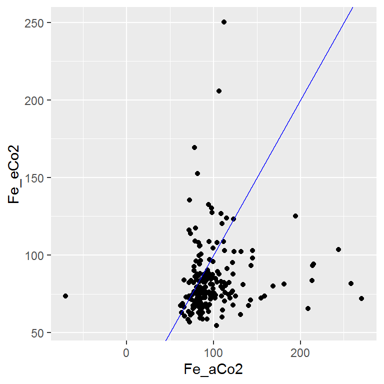

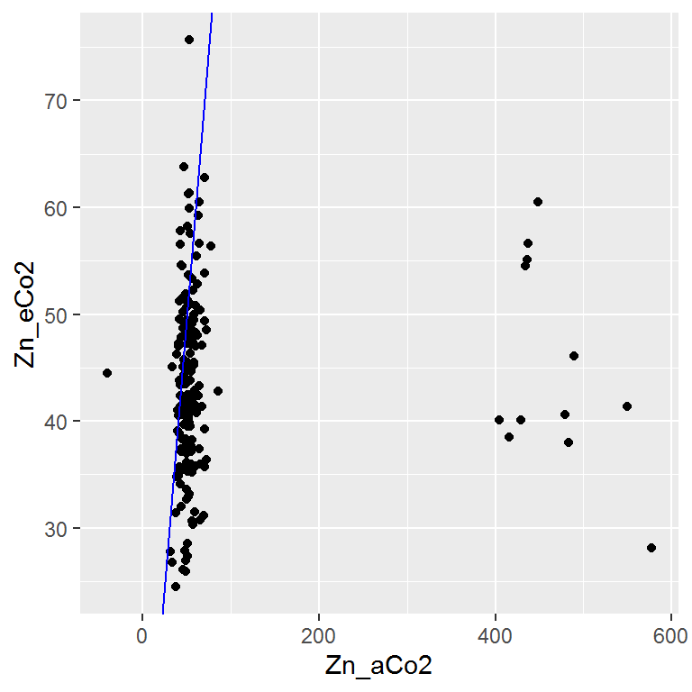

Comme le montrent ces deux Scatter plots,certaines valeurs pour certains éléments sont très singulières, et après discussion avec nos encadrants nous en avons conclu qu’il s’agit d’erreurs de mesures qui ne peuvent pas exister en réalité. Nous allons donc les supprimer.

## Suppression des outliers

```r
reg_no_out <- reg_clean
k= 3
for (i in 2:17) {
  binf <- median(reg_clean[,i]) - k* mad(reg_clean[,i])
  bsup <- median(reg_clean[,i]) + k* mad(reg_clean[,i])
  outlier_idx <- which(reg_no_out[,i] < binf | reg_no_out[,i] > bsup)
    if (length(outlier_idx) == 0) {
      reg_no_out = reg_no_out
    }
    else{
      reg_no_out = reg_no_out[-c(outlier_idx),]
      }
  #print(outlier_idx)
  }
```

Nous créons aussi un dataFrame qui garde les lignes qui contiennent des observations outlier et qui remplace juste ces observations par des NA’s.

```r
library(naniar)
k= 3

reg_no_out_NA <- reg_clean
for (i in 2:17) {
  binf <- median(reg_clean[,i]) - k* mad(reg_clean[,i])
  bsup <- median(reg_clean[,i]) + k* mad(reg_clean[,i])
  outlier_idx <- which(reg_no_out_NA[,i] < binf | reg_no_out_NA[,i] > bsup)
  if (length(outlier_idx) == 0) {
    reg_no_out_NA = reg_no_out_NA
  }
  else{
    reg_no_out_NA[c(outlier_idx),i] =NA
  }
}
```

On passe donc de 200 à 110 plantes, en enlevant les lignes avec des Na et les outliers

### Calcul des colonnes de variation sans les outliers

Comme nous avons supprimé les lignes contenant des outliers, ils nous faut recalculer les colonnes de variation pour chaque élément, ce qui nous donne ce nouveau DataFrame :

```
##   genotype  Cu_eCo2  Cu_aCo2  Fe_eCo2   Fe_aCo2  Mg_eCo2  Mg_aCo2  Mn_eCo2
## 1   ALL1-2       NA 6.163191 86.15235  79.04962 3073.099 3154.750 31.62240
## 2   CAM-16 7.535217 9.360830 72.33809 101.70416 2691.580 3168.768 27.37796
## 3   CAM-61 5.840226 7.459179 78.25903  99.68175 2418.438 3302.608 31.82923
## 4    CUR-3 7.688745 8.244113 75.64733 100.67810 2764.476 2983.869 37.20361
## 5      JEA 7.127952 5.260100 76.33806  77.89958 3324.155 2795.618 37.47923
## 6    LAC-3 8.041563 5.883676 77.49142  86.84305 3113.547 2514.212 36.30887
##    Mn_aCo2  Na_eCo2  Na_aCo2  Zn_eCo2  Zn_aCo2 C_eCo2 C_aCo2 N_eCo2 N_aCo2
## 1 26.52852 735.7809 775.4902 47.30910 56.27261 39.213 37.526  6.545  6.869
## 2 36.17834 793.7096 932.2881 46.96952 59.45392 39.356 38.909  6.570  7.362
## 3 30.51482 639.5047 827.7428 43.50968 48.37164 41.132 38.733  5.836  7.073
## 4 35.97431 755.2332 824.4113 35.96349 54.46111 40.420 39.423  6.825  7.202
## 5 28.05387 951.6965 835.3540 41.15817 44.58561 40.393 41.034  6.472  6.287
## 6 24.47609 537.5663 505.9961 44.35044 46.83406 39.583 40.274  6.440  6.339
##   N_change Fe_change Mg_change Mn_change Na_change Zn_change C_change Cu_change
## 1    -4.72      8.99     -2.59     19.20     -5.12    -15.93     4.50        NA
## 2   -10.76    -28.87    -15.06    -24.33    -14.86    -21.00     1.15    -19.50
## 3   -17.49    -21.49    -26.77      4.31    -22.74    -10.05     6.19    -21.70
## 4    -5.23    -24.86     -7.35      3.42     -8.39    -33.96     2.53     -6.74
## 5     2.94     -2.00     18.91     33.60     13.93     -7.69    -1.56     35.51
## 6     1.59    -10.77     23.84     48.34      6.24     -5.30    -1.72     36.68
```

## Première Visualisation : Variation moyenne des mesures entre le aCO2 et le eCO2

Nous avons ici voulu reproduire une visualisation qui avait été faite dans le cas du riz pour montrer la variation de chaque élément quand la plante est en condition de fort CO2 et quand elle est en condition de CO2 ambiant

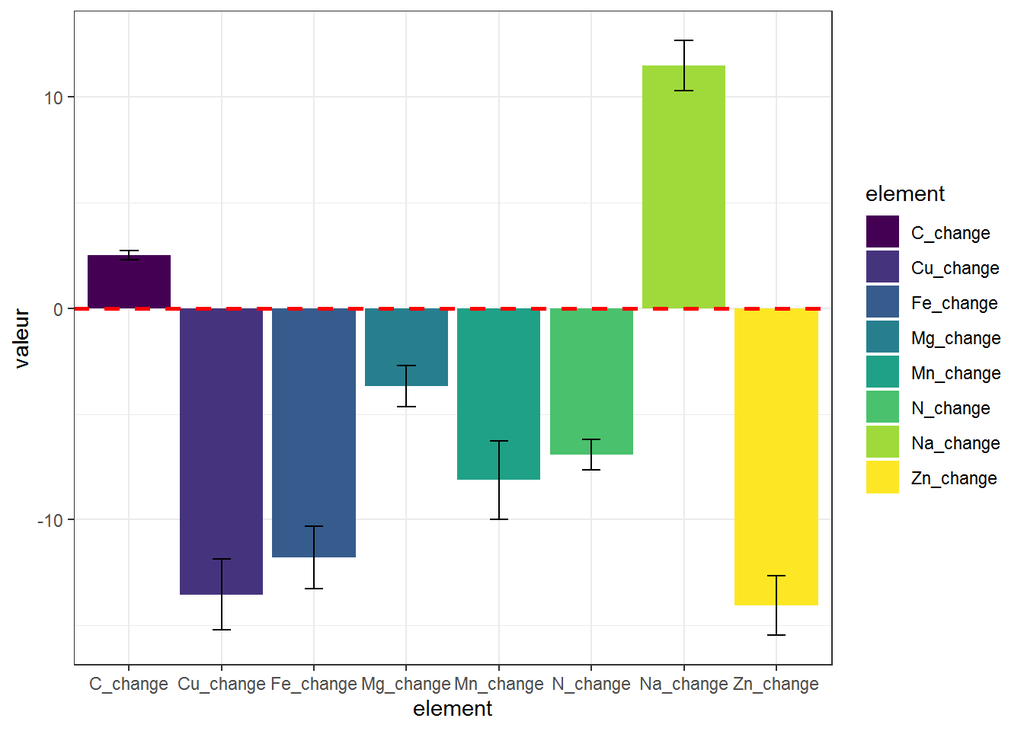

```r
ggplot(reg_chl, aes(element, valeur, fill = element))+
  stat_summary(fun = mean, geom = "bar") +
  stat_summary(fun.data = mean_se, geom = "errorbar", width = 0.2)+
  geom_hline(yintercept = 0, color = "red", linetype = "dashed", size = 1) +
  scale_fill_viridis_d() +
  scale_color_viridis_d() +
  theme_bw()
```

Observations :

## Scatter plots

Afin de visualiser d’une autre façon si il y a une perte de certains éléments quand la plante est en condition de fort CO2, nous avons créé des scatter plots.

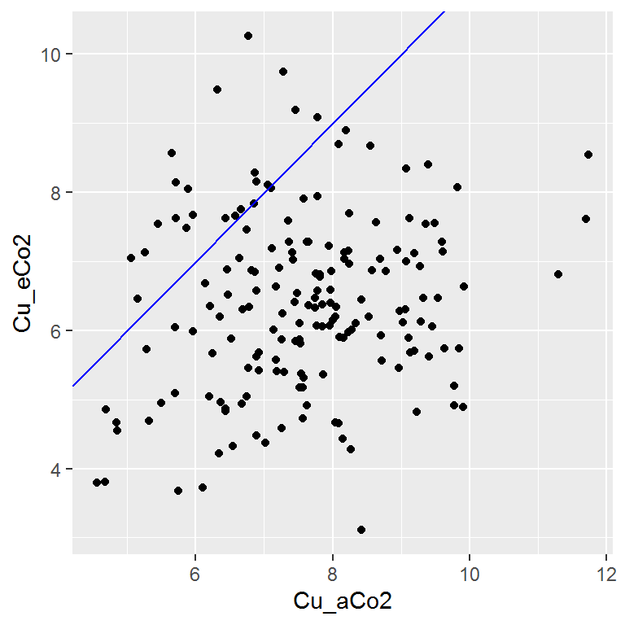

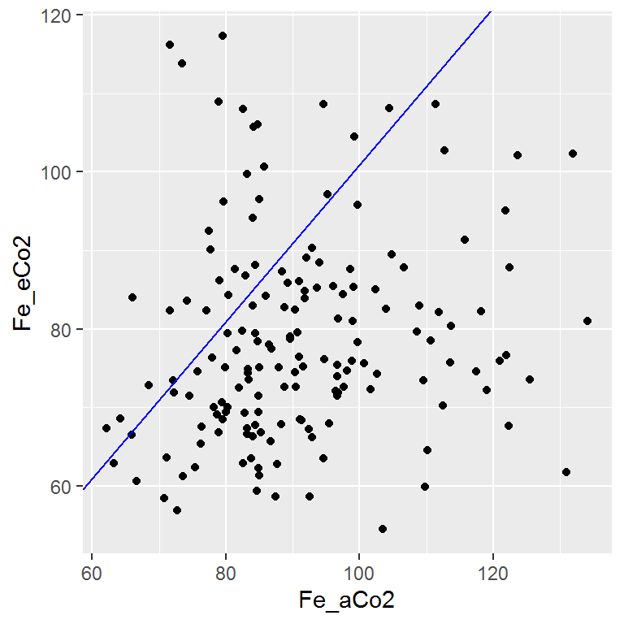

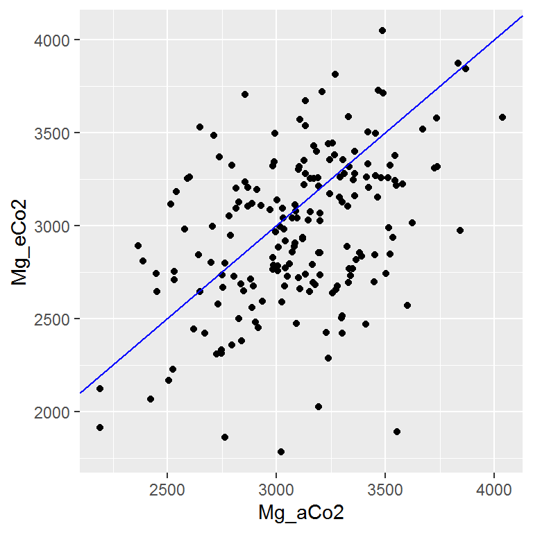

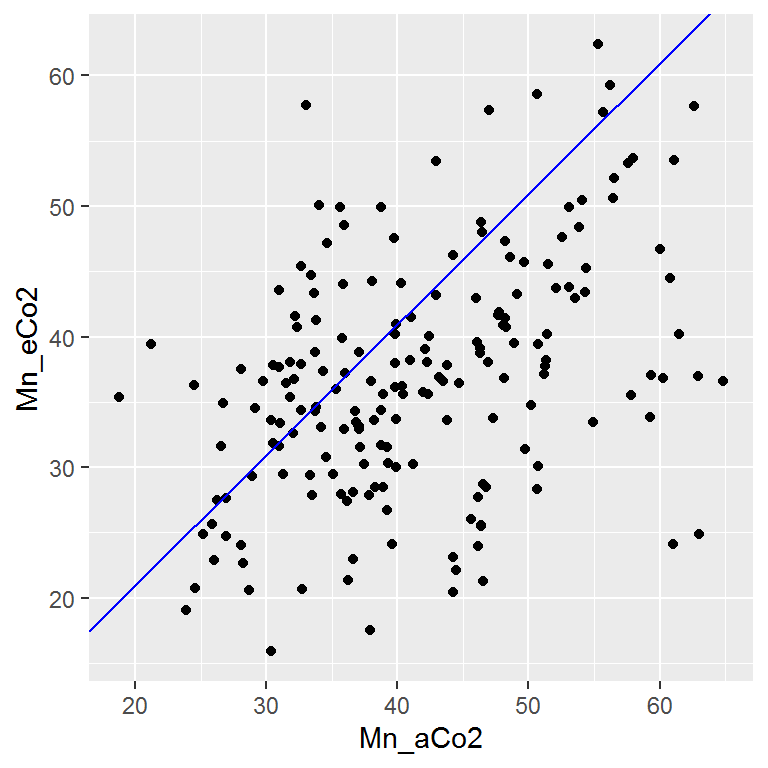

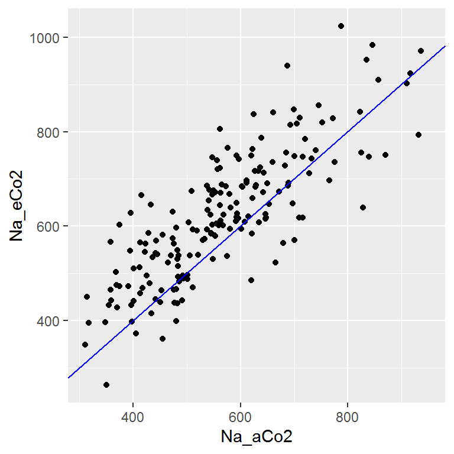

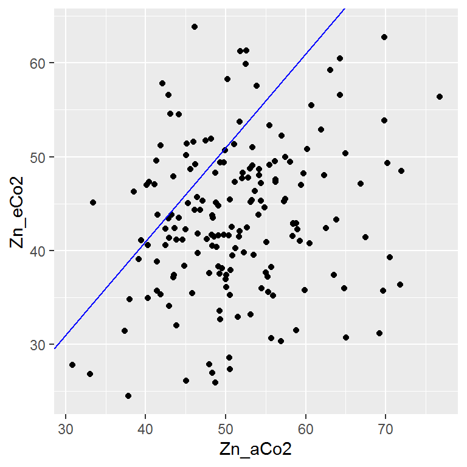

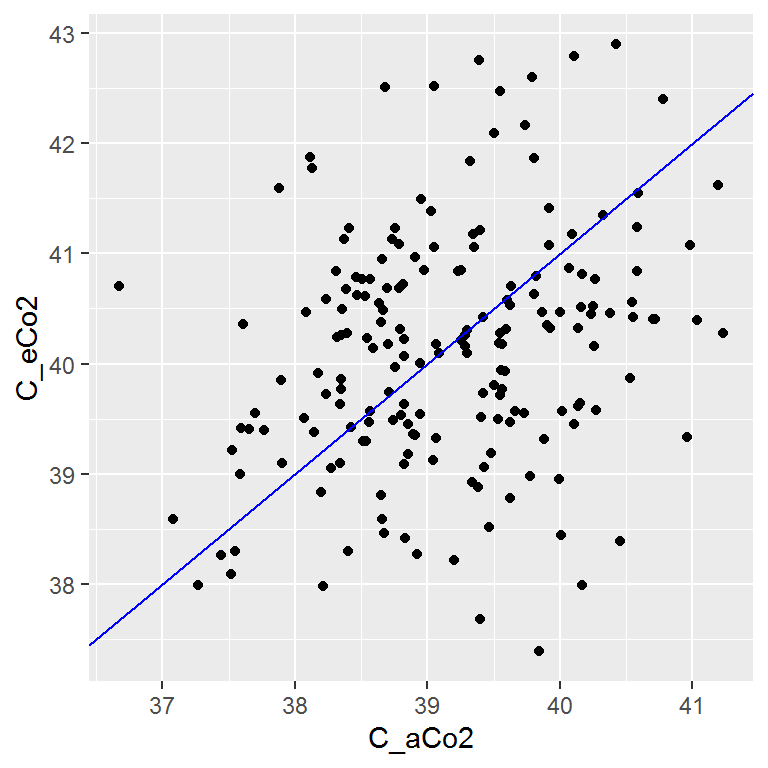

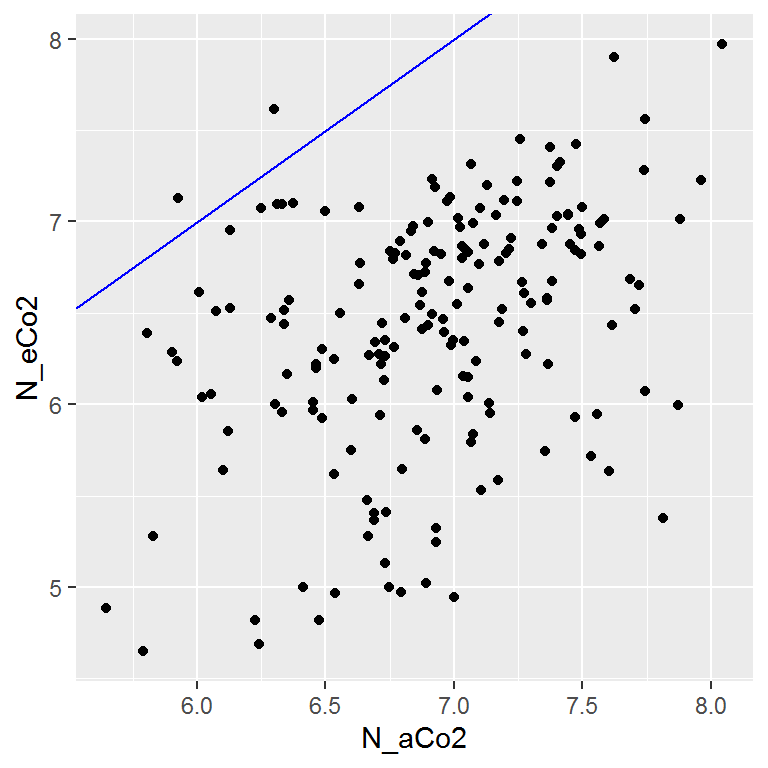

```r
i = 2
while (i < 17) {
  print(
    ggplot(data= reg_no_out_NA, aes(x =reg_no_out_NA[,i+1], y = reg_no_out_NA[,i]))+
    geom_point()+
    xlab(colnames(reg)[i+1]) + ylab(colnames(reg)[i])+
    geom_abline(slope = 1, intercept = 1,col="blue")
  )

i = i + 2}
```

## Distribution des données : Histogrammes et Violin plots

### Violin plots

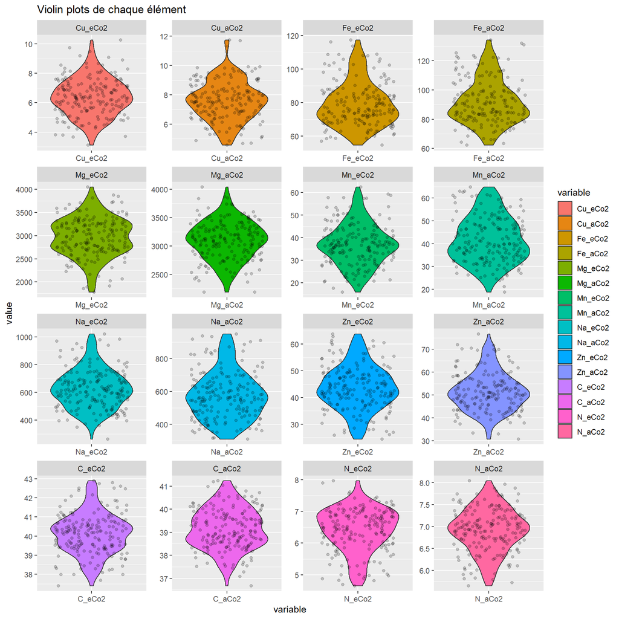

### Histogrammes

[figure not shown]

```r
i = 2
while (i < 18) {
  ggplot(data= reg_no_out_no_ch, aes(sample=reg_no_out_no_ch[,i]))+
    stat_qq()+
    facet_wrap(~reg_no_out_no_ch[,i],scales ="free")+
    ggtitle("qqplot de chaque élément")
  i=i+1
}
```

Après ces deux visualisations nous pouvons remarquer que les distributions ont l’air pour la plupart normales mais que des doutes quand à leur normalité persistent.

## Tests de normalité : Test de Shapiro

Dans le but de choisir des tests sur la moyenne et sur la variance adaptés à nos données, nous avons commencé par réaliser un test de normalité, ici le test de Shapiro.

Voici les p-values pour la distribution de chaque élément :

```
## [1] "Test de Shapiro entre les données Cu_eCo2"
## [1] 0.916066
## [1] "Test de Shapiro entre les données Cu_aCo2"
## [1] 0.1802243
## [1] "Test de Shapiro entre les données Fe_eCo2"
## [1] 1.625186e-05
## [1] "Test de Shapiro entre les données Fe_aCo2"
## [1] 0.0002177334
## [1] "Test de Shapiro entre les données Mg_eCo2"
## [1] 0.2672458
## [1] "Test de Shapiro entre les données Mg_aCo2"
## [1] 0.8398614
## [1] "Test de Shapiro entre les données Mn_eCo2"
## [1] 0.1593041
## [1] "Test de Shapiro entre les données Mn_aCo2"
```

[output cut: 17 more lines]

Ici, nous remarquons que les éléments dont la distribution suit une loi normale après avoir enlevé les outliers sont : C, Zn_e, Na_e, Mg et Cu, Mn, N_a,

### Test de significativité sur les moyennes : Wilcoxon

Ici on a choisi un test de Wilcoxon (car on ne respecte pas les pré-requis pour un test paramétrique pour toutes nos variables) pour des valeurs paired, car la mesure en Co2 ambiant et élevé sont réalisées sur les mêmes génotypes. Vous trouverez ci dessous des violin plots deux à deux et la p-value de chaque paire avec le test de Wilcoxon.

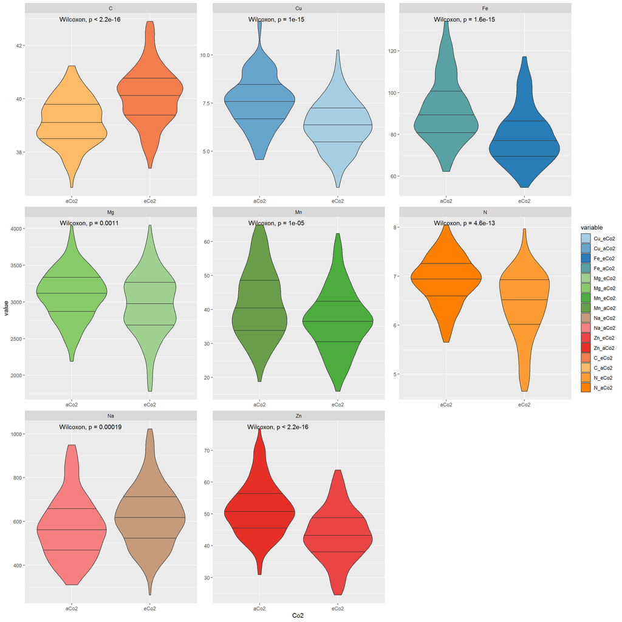

```r
library(ggplot2)
library(RColorBrewer)
library(ggpubr)

reg_long = melt(reg_no_out_no_ch)
reg_long$element = stringr::str_split_fixed(reg_long$variable, "_",2)[,1]
reg_long$Co2 = stringr::str_split_fixed(reg_long$variable, "_",2)[,2]

nb.cols <- 16
mycolors <- colorRampPalette(brewer.pal(8, "Paired"))(nb.cols)

ggplot(data = reg_long, aes(x = Co2, y = value)) +
  geom_violin(aes(fill = variable), draw_quantiles = c(0.25,0.5,0.75)) +
  facet_wrap( ~ element, scales = "free") +
  scale_fill_manual(values = mycolors) +
  stat_compare_means()
```

### Autre visualisation du résultat du test de Wilcoxon

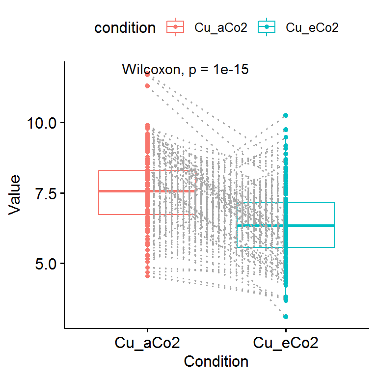

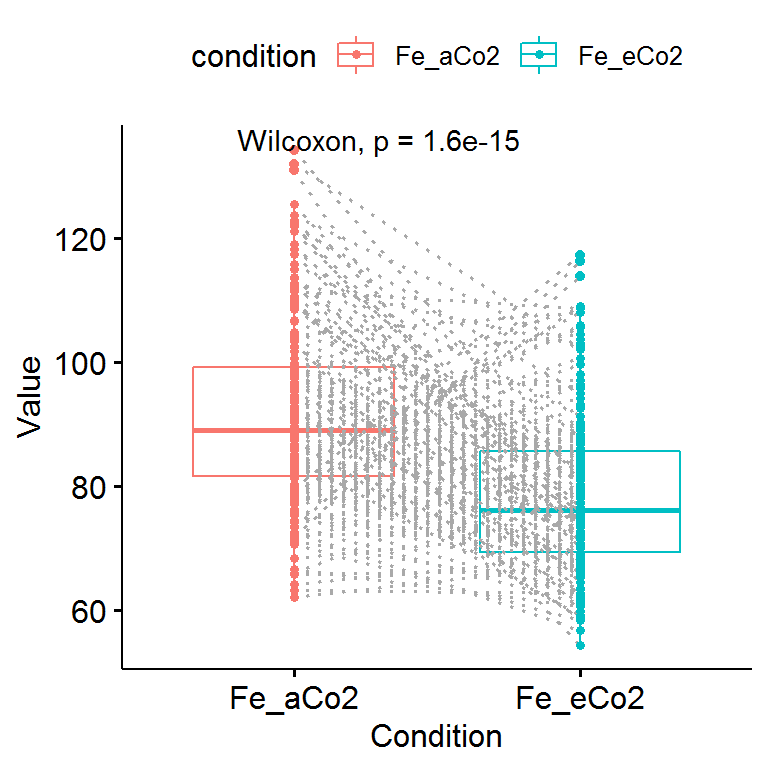

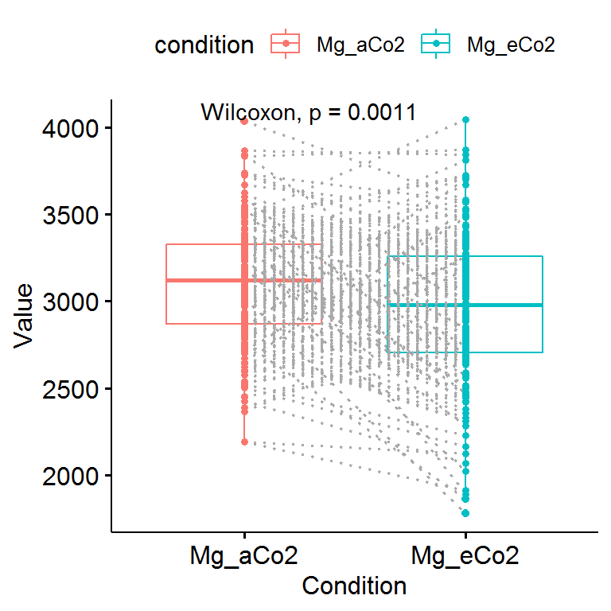

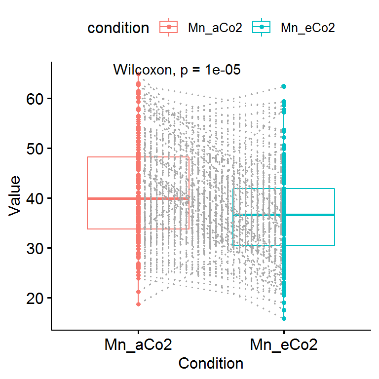

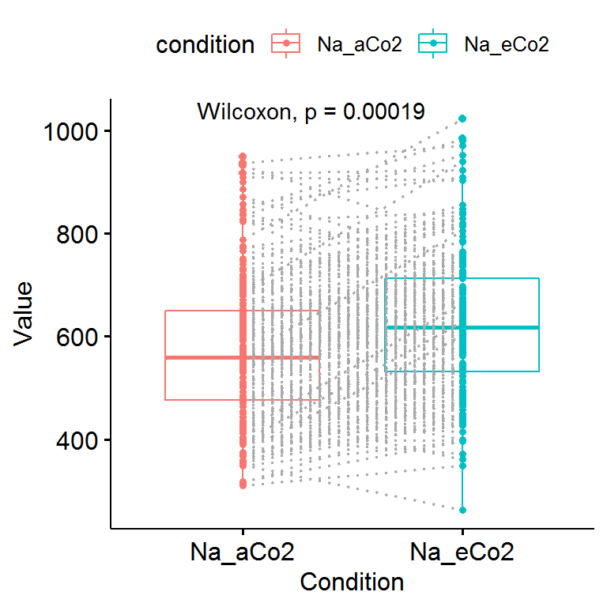

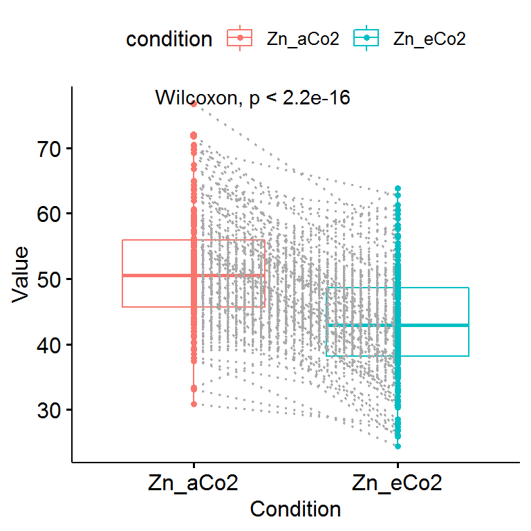

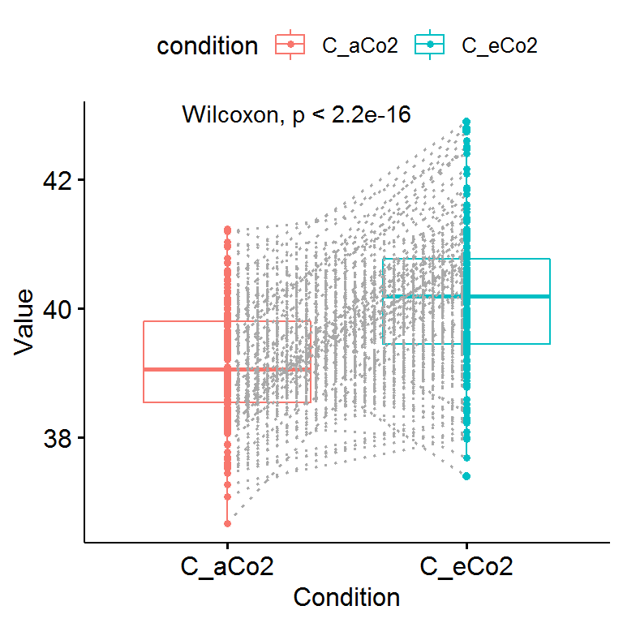

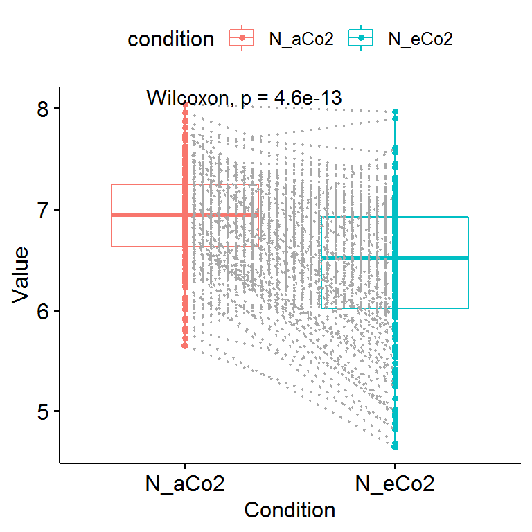

```r
i=2
while (i < 17) {
  plot_paired <- ggpaired(reg_no_out_NA, cond1 = names(reg_no_out_NA[i+1]) , cond2 = names(reg_no_out_NA[i]),
           line.color = "dark gray", line.size = 0.6, color = "condition",
           width = 0.7, linetype = "dotted" ,
           palette = "aas")+
    stat_compare_means()
  print(plot_paired)
  i = i+2
}
```

On peut constater en regardant les graphes et le p-values du test de Wilcoxon que les éléments Cu,Fe,Mg,Mn,Na,Zn,C et N ont des moyennent significativement différentes entre CO2 ambiant et élevé, soit tous les éléments.

### Test de significativité sur les moyennes pour les répartitions normales : Student

```
## [1] "Test de Student entre les données Mg_aCo2 et Mg_eCo2"
```

```
## [1] "p-value =  1.91547874883346e-05"
```

```
## [1] "Test de Student entre les données C_aCo2 et C_eCo2"
```

```
## [1] "p-value =  7.18761025585062e-22"
```

```
## [1] "Test de Student entre les données Cu_aCo2 et Cu_eCo2"
```

```
## [1] "p-value =  1.14343086803147e-16"
```

Ici, on observe que tous les éléments de distribution normales ont une moyenne significativement différente. Nous sommes donc encore plus assurés que les moyennes sont significativement différentes, même pour les éléements aux distributions normales.

### Test de significativité sur les variances pour les répartitions non normales : Levene

```
## [1] "Test de Levene entre les données Cu_eCo2 et Cu_aCo2"
## [1] "p-value =  0.591600273515121"
## [1] "Test de Levene entre les données Fe_eCo2 et Fe_aCo2"
## [1] "p-value =  0.0846952587293537"
## [1] "Test de Levene entre les données Mg_eCo2 et Mg_aCo2"
## [1] "p-value =  0.00225623773971855"
## [1] "Test de Levene entre les données Mn_eCo2 et Mn_aCo2"
## [1] "p-value =  0.0506518812862218"
## [1] "Test de Levene entre les données Na_eCo2 et Na_aCo2"
## [1] "p-value =  0.77466793388253"
## [1] "Test de Levene entre les données Zn_eCo2 et Zn_aCo2"
## [1] "p-value =  0.916833651713691"
## [1] "Test de Levene entre les données C_eCo2 et C_aCo2"
## [1] "p-value =  0.0859442347737079"
## [1] "Test de Levene entre les données N_eCo2 et N_aCo2"
## [1] "p-value =  0.000106166891506193"
```

### Test de significativité sur les variances pour les répartitions normales : Fisher

```
## [1] "Test de Fisher entre les données Mg_aCo2 et Mg_eCo2"
```

```
## [1] "p-value =  0.00330250289777073"
```

```
## [1] "Test de Fisher entre les données C_aCo2 et C_eCo2"
```

```
## [1] "p-value =  0.0104275772975238"
```

```
## [1] "Test de Fisher entre les données Cu_aCo2 et Cu_eCo2"
```

```
## [1] "p-value =  0.443105895081538"
```